# Capture-Mark-Recapture practical

## Generating capture histories

Install and load the packages we will be using in today’s practical: *tidyr* and *dplyr* for data manipulation, *marked* for the CMR analysis, *R2ucare* for goodness-of-fit testing and *ggplot2* for plotting.

```r
rm(list=ls(all=TRUE))

my_packages <- c('dplyr', 'tidyr', 'marked', 'ggplot2', 'R2ucare')
new_packages <- my_packages[!(my_packages %in% installed.packages()[,'Package'])]
if(length(new_packages)) install.packages(new_packages)

library(dplyr)
library(tidyr)
library(marked)
library(ggplot2)
library(R2ucare)
```

Load the sparrow recapture dataset - you’ll need to edit the file path to direct R to wherever you saved the data file.

```r
longdata <- read.table("~/Dropbox/Hannah/Work URF/Teaching/MSc/Practicals/CMR/sparrowrecap.txt", header = TRUE, sep = '\t')
head(longdata)
```

```
##      id year     island    sex
## 1 11243 1998 Hestmannoy Female
## 2 10905 1998     Gjeroy Female
## 3 10026 1998     Gjeroy   Male
## 4  2580 1998     Gjeroy   Male
## 5  4836 1998     Gjeroy Female
## 6  3342 1998     Gjeroy Female
```

The dataset consists of n=2378 capture observations across different islands in the house sparrow meta-population. These data are in what is known as ‘long format’, with individuals appearing in multiple rows representing each occasion they were captured. First a bit of simple data exploration:

```r
length(unique(longdata$id)) # the number of unique individuals in the dataframe
```

[output not shown]

```r
table(longdata$sex) # equal number of observations of males and females
```

```
##
## Female   Male
##   1189   1189
```

```r
table(longdata$year) # captures from 1998-2007
```

```
##
## 1998 1999 2000 2001 2002 2003 2004 2005 2006 2007
##  194  324  307  218  170  139  192  199  323  312
```

```r
table(longdata$island) # at 4 different island locations
```

```
##
##     Gjeroy Hestmannoy     Kvaroy      Myken
##        571       1353        337        117
```

*marked* requires capture histories to be in ‘wide’ format, with each row representing one individual. The capture history forms a string of 1s and 0s with no spaces, with a 1 for each capture or sighting and a 0 when an individual wasn’t detected. All histories should have the same number of entries and therefore be the same length. They should appear in the first column of the dataframe which must be named ‘ch’. The following code uses pipes (%>%) and the spread(), unite() and group_by() functions from the *tidyr* and *dplyr* packages to generate the appropriate format.

```r
temp <- longdata[,1:2] # take the first two columns, id and year and put into a temporary dataframe
temp$detect <- 1 # add column for detection (all 1s because these represent captures)

temp <- temp %>%
  # remove duplicates, which may occur when individuals are caught multiple times in an sampling event
  distinct() %>%
  # spread out data. The fill = 0 adds rows for combinations of id and year where individuals were not observed
  spread(year, detect, fill = 0) %>%
  # for every individual....
  group_by(id) %>%
  # paste together 0's and 1's using unite()
  # here we are pasting the strings together from the second column (first capture event)
  # to the last capture event ("tail(names(.),1)")
  # use sep="" so there are no characters separating 0's and 1's
  unite("ch", 2:tail(names(.),1), sep = "")

sparrow <- as.data.frame(temp) # new dataframe called sparrow
head(sparrow)
```

```
##    id         ch
## 1   1 0000100100
## 2  14 0001000000
## 3  18 1000000000
## 4  24 0000001000
## 5  57 0000001000
## 6 100 0000100000
```

We will now add back some information based on the individual ids using the match() function.

```r
sparrow$island <- longdata$island[match(sparrow$id, longdata$id)]
# this creates a new column called island in the sparrow df...
# using the entry from the island column in the longdata df...
# where id in the sparrow df matches the id in the longdata df

sparrow$sex <- as.factor(longdata$sex[match(sparrow$id, longdata$id)])

sparrow <- droplevels(subset(sparrow, select = -id)) # remove id column so capture histories appear in first column
head(sparrow)
```

```
##           ch     island    sex
## 1 0000100100 Hestmannoy   Male
## 2 0001000000      Myken Female
## 3 1000000000 Hestmannoy   Male
## 4 0000001000      Myken Female
## 5 0000001000     Gjeroy   Male
## 6 0000100000 Hestmannoy   Male
```

We are now ready to run a simple Capture-Mark-Recapture analysis.

## Simple Cormack-Jolly-Seber model

A CJS model estimates apparent survival (Phi) and detection probability (p) for open populations. Each of these is a linear model on the logit scale (bound between 0 and 1). This is the same transformation or ‘link function’ used in a binomial Generalised Linear Model (GLM), and the same approach you used to model presence/absence data in the species distribution modelling workshop.

The CJS model uses information from capture histories where individuals were marked, not observed, and subsequently seen at a later date to estimate detection probabilities. For example, comparing the number of individuals with a capture history of 101 vs 111 is informative about detection probability on the second sampling event.

The most basic form of the model (the default) estimates constant survival and detection probabilities.

```r
mod1 <- crm(sparrow) # capture-mark-recapture (cmr) model
mod1 # examine model and coefficient estimates
```

```
##
## crm Model Summary
##
## Npar :  2
## -2lnL:  2450.35
## AIC  :  2454.35
##
## Beta
##                   Estimate
## Phi.(Intercept) 0.07109326
## p.(Intercept)   0.32242446
```

```r
mod1 <- cjs.hessian(mod1) # refit model with precision estimates
```

As with a binomial GLM, these estimates are on the latent (logit) scale. We can transform them back to the data scale using the plogis() or predict() functions. The estimates on the data scale are also stored within the results section of the model under ‘reals’.

```r
mod1$results$reals
```

```
## $Phi
##   occ  estimate
## 1   9 0.5177658
##
## $p
##   occ estimate
## 1  10 0.579915
```

```r
plogis(mod1$results$beta$Phi)
```

```
## (Intercept)
##   0.5177658
```

```r
plogis(mod1$results$beta$p)
```

```
## (Intercept)
##    0.579915
```

```r
predict(mod1, newdata=data.frame(sex = c('Female', 'Male')), se=T) # N.b. In this case, there are no groups or covariates in the model and so the 'newdata' argument is not used
```

```
## $Phi
##   occ  estimate         se       lcl       ucl
## 1   1 0.5177658 0.01548384 0.4873893 0.5480116
##
## $p
##   occ estimate         se       lcl       ucl
## 1   2 0.579915 0.02558621 0.5291095 0.6290816
```

The probability of surviving between capture events was therefore 0.518, and the probability of detecting an animal during a capture event was 0.580.

## Unequal sampling intervals

This model assumes an equal time between each capture event. This assumption can be relaxed by including a vector of time intervals:

```r
mod2 <- crm(sparrow, time.intervals = c(1,2,1,1,1,1,1,3,4))
mod2$results$reals
```

```
## $Phi
##   occ  estimate
## 1   9 0.6857959
##
## $p
##   occ  estimate
## 1  10 0.5147669
```

## Including static covariates

The islands in the meta-population are all different, and it is possible that the probability of capturing an individual differs between islands. We can test this by adding some additional complexity to our model and allowing the detection probability to vary between islands.

In the *marked* package, this is a three stage process: (1) data processing, (2) building the design matrix, (3) set up and execute candidate models. These steps are a little complex but we will use the built-in functions in *marked* to help us. You can type ?process.data or ?make.design.matrix to get more information on these functions. It is also helpful to examine the outputs of the functions to see what is happening. The outputs are lists, rather than dataframes. You can examine the different components of the lists using double square brackets or by naming them with the $ sign.

```r
sparrow.proc <- process.data(sparrow) # built in function for data processing
```

```
## 950 capture histories collapsed into 234
```

```r
str(sparrow.proc)
```

```
## List of 12
##  $ data            :'data.frame':    234 obs. of  5 variables:
##   ..$ ch    : chr [1:234] "0,0,0,0,0,0,0,0,1,0" "0,0,0,0,0,0,0,0,1,0" "0,0,0,0,0,0,0,0,1,0" "0,0,0,0,0,0,0,0,1,0" ...
##   ..$ island: chr [1:234] "Gjeroy" "Gjeroy" "Hestmannoy" "Hestmannoy" ...
##   ..$ sex   : Factor w/ 2 levels "Female","Male": 1 2 1 2 1 2 1 2 1 2 ...
##   ..$ freq  : num [1:234] 8 7 16 11 7 8 1 3 17 16 ...
##   ..$ id    : Factor w/ 234 levels "1","2","3","4",..: 1 2 3 4 5 6 7 8 9 10 ...
##  $ model           : chr "CJS"
##  $ mixtures        : NULL
##  $ freq            : num [1:234, 1] 8 7 16 11 7 8 1 3 17 16 ...
##   ..- attr(*, "dimnames")=List of 2
##   .. ..$ : chr [1:234] "1" "2" "3" "4" ...
##   .. ..$ : chr "group1"
##  $ nocc            : num 10
##  $ nocc.secondary  : NULL
##  $ time.intervals  : num [1:9] 1 1 1 1 1 1 1 1 1
##  $ begin.time      : num 1
##  $ initial.ages    : num 0
##  $ group.covariates: NULL
##  $ start           : num [1:234, 1:2] NA NA NA NA NA NA NA NA NA NA ...
##   ..- attr(*, "dimnames")=List of 2
##   .. ..$ : chr [1:234] "0,0,0,0,0,0,0,0,1,0" "0,0,0,0,0,0,0,0,1,0" "0,0,0,0,0,0,0,0,1,0" "0,0,0,0,0,0,0,0,1,0" ...
##   .. ..$ : NULL
##  $ ehmat           : num [1:234, 1:10] 0 0 0 0 0 0 0 0 0 0 ...
```

```r
head(sparrow.proc[[1]])
```

```
##                      ch     island    sex freq id
## 191 0,0,0,0,0,0,0,0,1,0     Gjeroy Female    8  1
## 249 0,0,0,0,0,0,0,0,1,0     Gjeroy   Male    7  2
## 229 0,0,0,0,0,0,0,0,1,0 Hestmannoy Female   16  3
## 46  0,0,0,0,0,0,0,0,1,0 Hestmannoy   Male   11  4
## 11  0,0,0,0,0,0,0,0,1,0     Kvaroy Female    7  5
## 133 0,0,0,0,0,0,0,0,1,0     Kvaroy   Male    8  6
```

```r
head(sparrow.proc$data)
```

```
##                      ch     island    sex freq id
## 191 0,0,0,0,0,0,0,0,1,0     Gjeroy Female    8  1
## 249 0,0,0,0,0,0,0,0,1,0     Gjeroy   Male    7  2
## 229 0,0,0,0,0,0,0,0,1,0 Hestmannoy Female   16  3
## 46  0,0,0,0,0,0,0,0,1,0 Hestmannoy   Male   11  4
## 11  0,0,0,0,0,0,0,0,1,0     Kvaroy Female    7  5
## 133 0,0,0,0,0,0,0,0,1,0     Kvaroy   Male    8  6
```

```r
sparrow.ddl <- make.design.data(sparrow.proc) # built in function for building design matrix
str(sparrow.ddl)
```

```
## List of 4
##  $ Phi              :'data.frame':   2106 obs. of  12 variables:
##   ..$ id    : Factor w/ 234 levels "1","2","3","4",..: 1 1 1 1 1 1 1 1 1 2 ...
##   ..$ occ   : int [1:2106] 1 2 3 4 5 6 7 8 9 1 ...
##   ..$ time  : Factor w/ 9 levels "1","2","3","4",..: 1 2 3 4 5 6 7 8 9 1 ...
##   ..$ cohort: Factor w/ 9 levels "1","2","3","4",..: 9 9 9 9 9 9 9 9 9 9 ...
##   ..$ age   : Factor w/ 9 levels "0","1","2","3",..: 1 1 1 1 1 1 1 1 1 1 ...
##   ..$ island: chr [1:2106] "Gjeroy" "Gjeroy" "Gjeroy" "Gjeroy" ...
##   ..$ sex   : Factor w/ 2 levels "Female","Male": 1 1 1 1 1 1 1 1 1 2 ...
##   ..$ freq  : num [1:2106] 8 8 8 8 8 8 8 8 8 7 ...
##   ..$ Time  : num [1:2106] 0 1 2 3 4 5 6 7 8 0 ...
##   ..$ Cohort: num [1:2106] 8 8 8 8 8 8 8 8 8 8 ...
##   ..$ Age   : num [1:2106] 0 0 0 0 0 0 0 0 0 0 ...
##   ..$ order : int [1:2106] 1 2 3 4 5 6 7 8 9 10 ...
##  $ p                :'data.frame':   2106 obs. of  13 variables:
##   ..$ id    : Factor w/ 234 levels "1","2","3","4",..: 1 1 1 1 1 1 1 1 1 2 ...
##   ..$ occ   : int [1:2106] 2 3 4 5 6 7 8 9 10 2 ...
##   ..$ time  : Factor w/ 9 levels "2","3","4","5",..: 1 2 3 4 5 6 7 8 9 1 ...
##   ..$ cohort: Factor w/ 9 levels "1","2","3","4",..: 9 9 9 9 9 9 9 9 9 9 ...
##   ..$ age   : Factor w/ 10 levels "0","1","2","3",..: 1 1 1 1 1 1 1 1 2 1 ...
##   ..$ island: chr [1:2106] "Gjeroy" "Gjeroy" "Gjeroy" "Gjeroy" ...
##   ..$ sex   : Factor w/ 2 levels "Female","Male": 1 1 1 1 1 1 1 1 1 2 ...
##   ..$ freq  : num [1:2106] 8 8 8 8 8 8 8 8 8 7 ...
##   ..$ Time  : num [1:2106] 0 1 2 3 4 5 6 7 8 0 ...
##   ..$ Cohort: num [1:2106] 8 8 8 8 8 8 8 8 8 8 ...
##   ..$ Age   : num [1:2106] 0 0 0 0 0 0 0 0 1 0 ...
##   ..$ fix   : num [1:2106] 0 0 0 0 0 0 0 1 NA 0 ...
##   ..$ order : int [1:2106] 1 2 3 4 5 6 7 8 9 10 ...
##  $ design.parameters:List of 2
##   ..$ Phi:List of 14
##   .. ..$ begin      : num 0
##   .. ..$ num        : num -1
##   .. ..$ default    : num 1
##   .. ..$ type       : chr "Triang"
##   .. ..$ link       : chr "logit"
##   .. ..$ formula    :Class 'formula'  language ~1
##   .. .. .. ..- attr(*, ".Environment")=<environment: 0x1209064b0>
##   .. ..$ bystratum  : logi FALSE
##   .. ..$ tostrata   : logi FALSE
##   .. ..$ cjs        : logi FALSE
##   .. ..$ whichlevel : num 0
##   .. ..$ interval   : logi TRUE
##   .. ..$ nointercept: logi FALSE
##   .. ..$ obs        : logi FALSE
##   .. ..$ firstonly  : chr "FALSE"
##   ..$ p  :List of 14
##   .. ..$ begin      : num 1
##   .. ..$ num        : num -1
##   .. ..$ default    : num 0
##   .. ..$ type       : chr "Triang"
##   .. ..$ link       : chr "logit"
##   .. ..$ formula    :Class 'formula'  language ~1
##   .. .. .. ..- attr(*, ".Environment")=<environment: 0x1209064b0>
##   .. ..$ bystratum  : logi FALSE
##   .. ..$ tostrata   : logi FALSE
##   .. ..$ cjs        : logi TRUE
##   .. ..$ whichlevel : num 0
##   .. ..$ interval   : logi FALSE
##   .. ..$ nointercept: logi FALSE
##   .. ..$ obs        : logi FALSE
##   .. ..$ firstonly  : chr "FALSE"
##  $ ehmat            : num [1:234, 1:10] 0 0 0 0 0 0 0 0 0 0 ...
```

```r
head(sparrow.ddl[[1]])
```

```
##   id occ time cohort age island    sex freq Time Cohort Age order
## 1  1   1    1      9   0 Gjeroy Female    8    0      8   0     1
## 2  1   2    2      9   0 Gjeroy Female    8    1      8   0     2
## 3  1   3    3      9   0 Gjeroy Female    8    2      8   0     3
## 4  1   4    4      9   0 Gjeroy Female    8    3      8   0     4
## 5  1   5    5      9   0 Gjeroy Female    8    4      8   0     5
## 6  1   6    6      9   0 Gjeroy Female    8    5      8   0     6
```

```r
head(sparrow.ddl$Phi)
```

```
##   id occ time cohort age island    sex freq Time Cohort Age order
## 1  1   1    1      9   0 Gjeroy Female    8    0      8   0     1
## 2  1   2    2      9   0 Gjeroy Female    8    1      8   0     2
## 3  1   3    3      9   0 Gjeroy Female    8    2      8   0     3
## 4  1   4    4      9   0 Gjeroy Female    8    3      8   0     4
## 5  1   5    5      9   0 Gjeroy Female    8    4      8   0     5
## 6  1   6    6      9   0 Gjeroy Female    8    5      8   0     6
```

We can then specify the model formulation for the detection probability model, making p dependent on island. Finally, we run the CMR model using our newly processed data, our design matrix, and our model specification.

```r
# specify model formulation: capture probability depends on island
p.island <- list(formula=~island)

mod3 <- crm(sparrow.proc,
            sparrow.ddl,
            model.parameters = list(p = p.island),
            accumulate=FALSE, hessian = TRUE)
```

```r
mod3$results$reals
```

```
## $Phi
##   occ  estimate         se       lcl       ucl
## 1   9 0.5281824 0.01568172 0.4973782 0.5587734
##
## $p
##       island occ  estimate         se       lcl       ucl
## 1     Gjeroy  10 0.6408165 0.04084983 0.5575085 0.7164181
## 2 Hestmannoy  10 0.6117611 0.03381430 0.5438062 0.6756314
## 3     Kvaroy  10 0.4606557 0.06147297 0.3446468 0.5810895
## 4      Myken  10 0.1751286 0.04742340 0.1003680 0.2877636
```

#### *QUESTIONS: Does it look like detection probability varies among islands? Which island has the lowest detection probability? Why might this be? How might you compare this model with our simpler model above to see if it is a better fit?*

**Click me**

```r
(mod3$results$AIC)
```

```
## [1] 2423.197
```

```r
(mod1$results$AIC)
```

```
## [1] 2454.35
```

Lower AIC values indicate a better fitting model, so we accept the model with varying detection probabilities.

#### *TASK: Test whether survival probabilities differ between the islands*

Try coding this yourself before clicking below to reveal the answer.

Hint: first include the island term in the survival (Phi) model, then compare the AIC value with mod3 to see if this improves model fit.

**Click me**

```r
sparrow.proc <- process.data(sparrow)
sparrow.ddl <- make.design.data(sparrow.proc)

Phi.island <- list(formula=~island) # survival probability depends on island
p.island <- list(formula=~island) # capture probability depends on island

mod4 <- crm(sparrow.proc,
            sparrow.ddl,
            model.parameters = list(Phi = Phi.island,
                                    p = p.island),
            accumulate=FALSE, hessian = TRUE)
```

[output not shown]

```r
mod4$results$reals
```

```
## $Phi
##       island occ  estimate         se       lcl       ucl
## 1     Gjeroy   9 0.5742466 0.02826612 0.5181410 0.6285034
## 2 Hestmannoy   9 0.5119705 0.02079319 0.4712266 0.5525559
## 3     Kvaroy   9 0.4625529 0.04637814 0.3738524 0.5536888
## 4      Myken   9 0.6018275 0.09959830 0.4009394 0.7734199
##
## $p
##       island occ  estimate         se        lcl       ucl
## 1     Gjeroy  10 0.6134897 0.04445464 0.52361976 0.6962409
## 2 Hestmannoy  10 0.6243702 0.03504249 0.55361488 0.6901866
## 3     Kvaroy  10 0.5252580 0.07754841 0.37556476 0.6705455
## 4      Myken  10 0.1407425 0.05732845 0.06075255 0.2931769
```

```r
(mod4$results$AIC)
```

```
## [1] 2423.455
```

```r
(mod3$results$AIC)
```

```
## [1] 2423.197
```

The AIC value of the new model is slightly higher, indicating that including this extra term does not improve model fit. We therefore find no evidence that survival rates vary among islands.

### Does survival probability vary between the sexes?

To answer this question, we might want to test a few different model structures for both survival and detection components. We can make this easier by using a wrapper function like below.

```r
sparrow.proc <- process.data(sparrow)
sparrow.ddl <- make.design.data(sparrow.proc)

fit.models <- function() {
  Phi.dot <- list(formula=~1) # constant survival
  Phi.sex <- list(formula=~sex) # survival differs between sexes
  Phi.island <- list(formula=~island) # survival differs between islands
  Phi.sex.island <- list(formula=~sex+island) # survival differs between sexes and islands
  p.dot <- list(formula=~1) # constant detection
  p.sex <- list(formula=~sex) # detection probability differs between sexes
  p.island <- list(formula=~island) # detection probability differs between islands
  p.sex.island <- list(formula=~sex+island) # detection probability differs between sexes and islands
  cml <- create.model.list(c("Phi","p"))
  results <- crm.wrapper(cml, data=sparrow.proc, ddl=sparrow.ddl,
                         external=FALSE, accumulate=FALSE, hessian=TRUE)
  return(results)
}

sparrow.models <- fit.models() # run function
```

```r
sparrow.models # display model table
```

```
##                                 model npar      AIC   DeltaAIC       weight
## 2                   Phi(~1)p(~island)    5 2423.197  0.0000000 1.979268e-01
## 10                Phi(~sex)p(~island)    6 2423.437  0.2405004 1.755014e-01
## 6              Phi(~island)p(~island)    8 2423.455  0.2581163 1.739624e-01
## 14       Phi(~sex + island)p(~island)    9 2423.544  0.3470819 1.663936e-01
## 4             Phi(~1)p(~sex + island)    6 2424.848  1.6512849 8.668273e-02
## 8        Phi(~island)p(~sex + island)    9 2425.204  2.0070459 7.255713e-02
## 12          Phi(~sex)p(~sex + island)    7 2425.434  2.2376591 6.465514e-02
## 16 Phi(~sex + island)p(~sex + island)   10 2425.511  2.3145446 6.221679e-02
## 5                   Phi(~island)p(~1)    5 2440.324 17.1267399 3.779899e-05
## 13            Phi(~sex + island)p(~1)    6 2440.377 17.1800557 3.680466e-05
## 7                 Phi(~island)p(~sex)    6 2442.111 18.9137636 1.546796e-05
## 15          Phi(~sex + island)p(~sex)    7 2442.325 19.1282787 1.389478e-05
## 1                        Phi(~1)p(~1)    2 2454.350 31.1534941 3.401021e-08
## 9                      Phi(~sex)p(~1)    3 2454.659 31.4623029 2.914421e-08
```

[output cut: 19 more lines]

The top model (with the lowest AIC value) includes a constant model for survival probability with detection probabilities differing among islands. In fact, there are a number of models with very similar AIC scores, indicating a similar level of support. However, AIC differences of less than 2 are not considered to be meaningfully different and so in this case we accept the simplest model - that with the fewest parameters. In this case, that is the top model. We can extract and plot the different detection probabilities as follows.

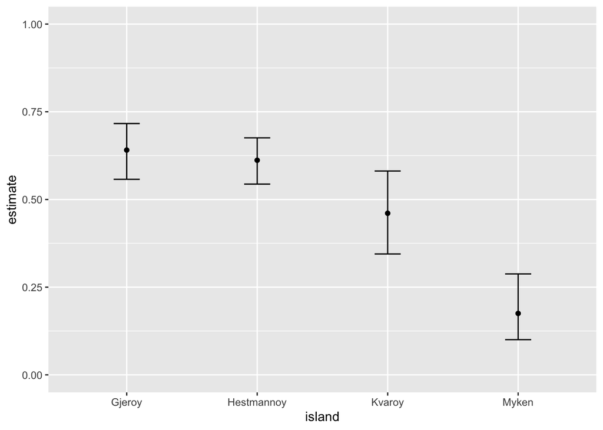

```r
mod5 <- sparrow.models[[2]]

ggplot(mod5$results$reals$p, aes(island, estimate, ymin=lcl, ymax=ucl)) +
  geom_errorbar(width=0.2) + geom_point() + ylim(0,1)
```

We can also extract the sex and island differences in survival from the similarly supported models and plot those to convince ourselves that there aren’t big differences.

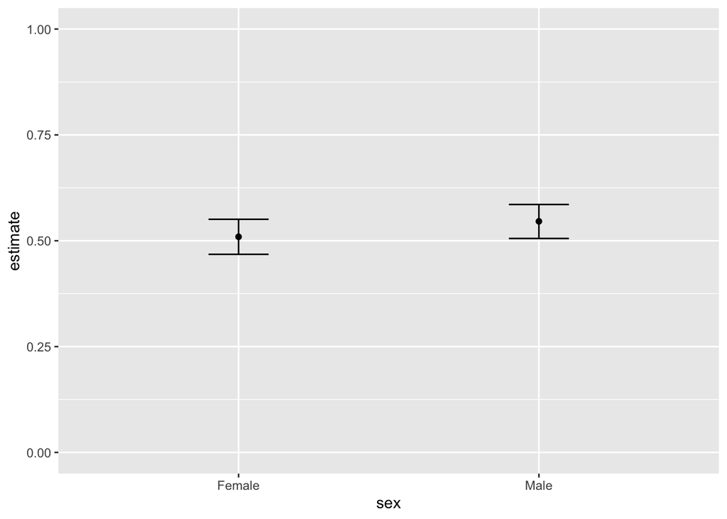

```r
mod6 <- sparrow.models[[10]]
ggplot(mod6$results$reals$Phi, aes(sex, estimate, ymin=lcl, ymax=ucl)) +
  geom_errorbar(width=0.2) + geom_point() + ylim(0,1)
```

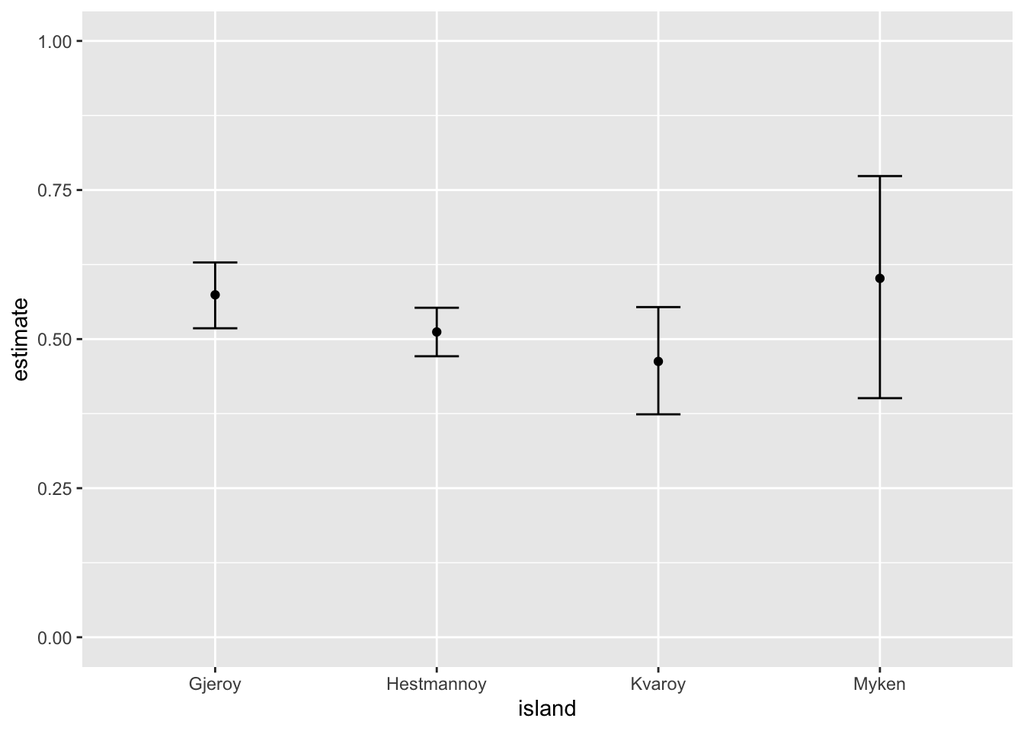

```r
mod7 <- sparrow.models[[6]]
ggplot(mod7$results$reals$Phi, aes(island, estimate, ymin=lcl, ymax=ucl)) +
  geom_errorbar(width=0.2) + geom_point() + ylim(0,1)
```

## Including time-varying covariates

We might want to test whether survival (or detection) probabilities differ depending on a factor that varies over time, such as some aspect of the weather. As an example, we will add a variable ‘cold’ to the design data (sparrow.ddl) and test whether it being an extra-cold winter affects survival.

```r
sparrow.ddl$Phi$cold <- "Cold" # new column
sparrow.ddl$Phi$cold[sparrow.ddl$Phi$time==2 | sparrow.ddl$Phi$time==5 | sparrow.ddl$Phi$time==8] <- "VeryCold" # very cold winters between capture events 2 and 3, 5 and 6, and 8 and 9

head(sparrow.ddl$Phi)
```

```
##   id occ time cohort age island    sex freq Time Cohort Age order     cold
## 1  1   1    1      9   0 Gjeroy Female    8    0      8   0     1     Cold
## 2  1   2    2      9   0 Gjeroy Female    8    1      8   0     2 VeryCold
## 3  1   3    3      9   0 Gjeroy Female    8    2      8   0     3     Cold
## 4  1   4    4      9   0 Gjeroy Female    8    3      8   0     4     Cold
## 5  1   5    5      9   0 Gjeroy Female    8    4      8   0     5 VeryCold
## 6  1   6    6      9   0 Gjeroy Female    8    5      8   0     6     Cold
```

```r
Phi.cold <- list(formula=~cold)
p.island <- list(formula=~island)

mod8 <- crm(sparrow.proc,
            sparrow.ddl,
            model.parameters = list(Phi = Phi.cold,
                                    p = p.island),
            accumulate=FALSE, hessian = TRUE)
```

```r
mod8$results$reals
```

```
## $Phi
##       cold occ  estimate         se       lcl       ucl
## 1     Cold   9 0.5260700 0.02119947 0.4844344 0.5673461
## 2 VeryCold   8 0.5320163 0.03043142 0.4721977 0.5909285
##
## $p
##       island occ  estimate         se       lcl       ucl
## 1     Gjeroy  10 0.6408431 0.04085442 0.5575246 0.7164519
## 2 Hestmannoy  10 0.6117678 0.03381891 0.5438033 0.6756463
## 3     Kvaroy  10 0.4605659 0.06147116 0.3445652 0.5810014
## 4      Myken  10 0.1751109 0.04741661 0.1003606 0.2877301
```

```r
(mod8$results$AIC)
```

```
## [1] 2425.175
```

```r
(mod5$results$AIC)
```

```
## [1] 2423.197
```

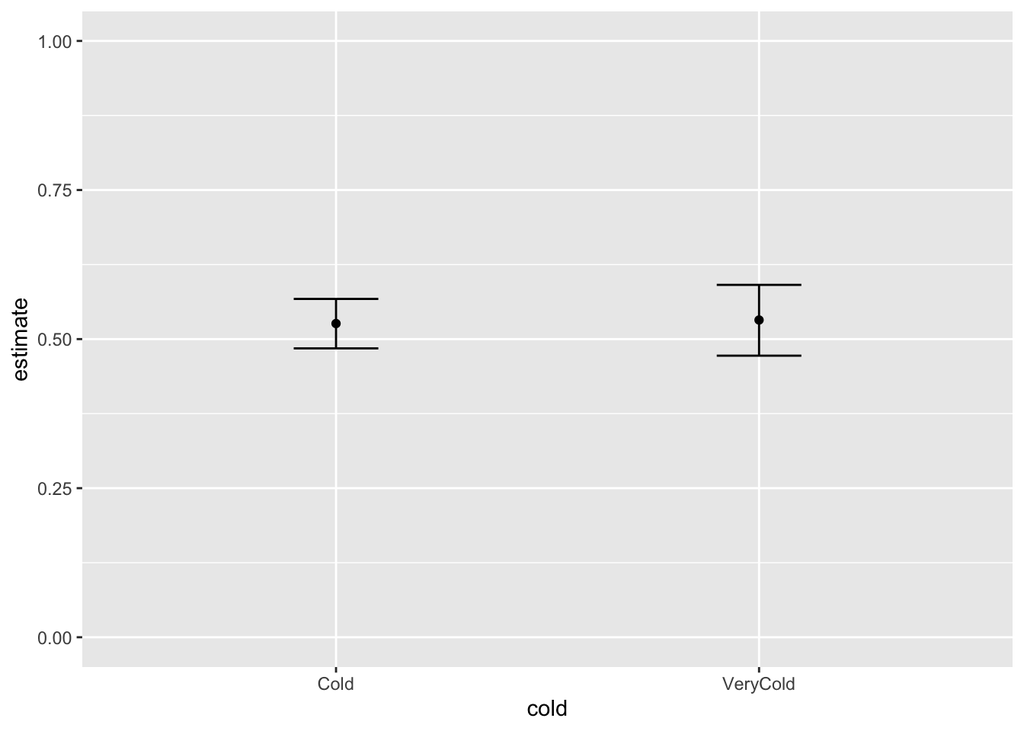

```r
ggplot(mod8$results$reals$Phi, aes(cold, estimate, ymin=lcl, ymax=ucl)) +
  geom_errorbar(width=0.2) + geom_point() + ylim(0,1)
```

The model including an effect of cold on survival probability has a higher AIC, so there is no evidence that survival varied depending on our made-up variable.

## Time varying survival and recapture probabilities

Finally, we can test whether survival and detection probabilities varied each year of the study period using the built-in time variable.

```r
sparrow.proc <- process.data(sparrow)
sparrow.ddl <- make.design.data(sparrow.proc)

fit.models <- function() {
  Phi.dot <- list(formula=~1) # constant survival
  Phi.time <- list(formula=~time) # survival varies over time
  p.island <- list(formula=~island) # detection probability differs between islands
  p.time <- list(formula=~time) # detection probability varies over time
  p.island.time <- list(formula=~island+time) # detection probability varies over time
  cml <- create.model.list(c("Phi","p"))
  results <- crm.wrapper(cml, data=sparrow.proc, ddl=sparrow.ddl,
                         external=FALSE, accumulate=FALSE, hessian=TRUE)
  return(results)
}

sparrow.models <- fit.models() # run function
```

```r
sparrow.models # display model table
```

```
##                         model npar      AIC   DeltaAIC       weight  neg2lnl
## 2    Phi(~1)p(~island + time)   13 2386.584  0.0000000 5.492732e-01 2360.584
## 5 Phi(~time)p(~island + time)   21 2386.979  0.3955145 4.507166e-01 2344.979
## 4        Phi(~time)p(~island)   13 2409.555 22.9715917 5.643787e-06 2383.555
## 3             Phi(~1)p(~time)   10 2410.266 23.6822663 3.955939e-06 2390.266
## 6          Phi(~time)p(~time)   18 2413.945 27.3617392 6.284377e-07 2377.945
## 1           Phi(~1)p(~island)    5 2423.197 36.6131514 6.156638e-09 2413.197
##   convergence
## 2           0
## 5           0
## 4           0
## 3           0
## 6           0
## 1           0
```

```r
mod9 <- sparrow.models[[2]]

(mod9$results$AIC)
```

```
## [1] 2386.584
```

```r
(mod5$results$AIC)
```

```
## [1] 2423.197
```

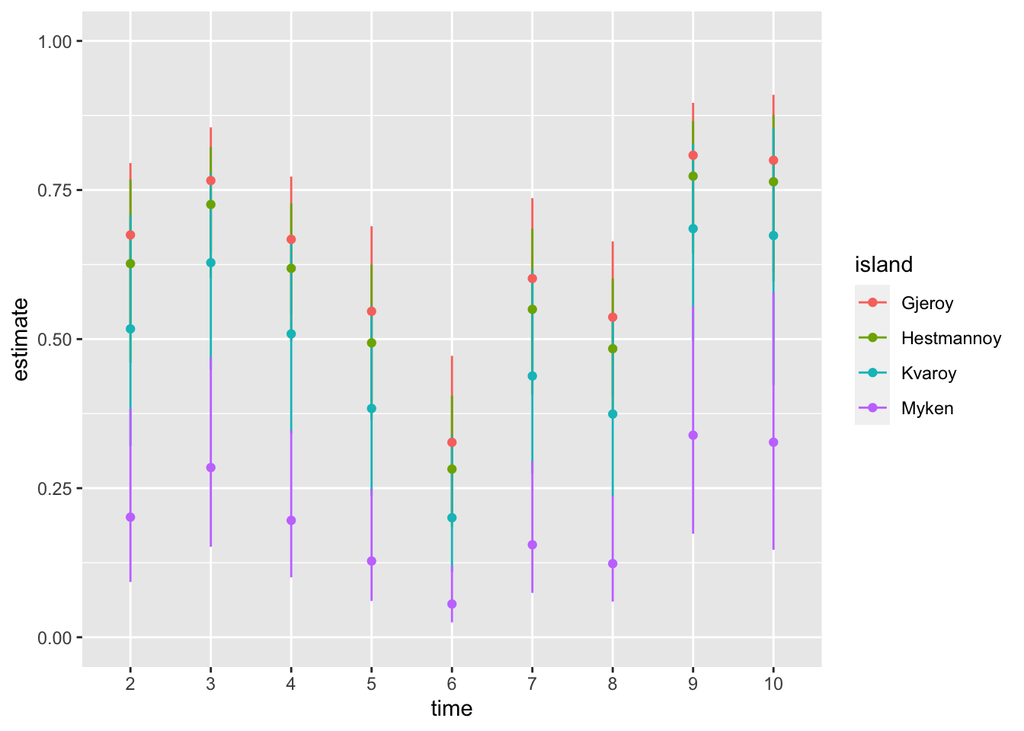

```r
ggplot(mod9$results$reals$p, aes(time, estimate, ymin=lcl, ymax=ucl, col=island)) +
  geom_errorbar(width=0) + geom_point() + ylim(0,1)
```

It seems that detection probabilities varied over time.

## Goodness-of-fit tests (if you get this far…)

To test whether our data violate any of the basic assumptions of the CJS model, we can use the package *R2ucare*. This package contains functions to perform goodness-of-fit tests for CMR models. In particular, this package will test whether our data violate the ‘equal detection assumption’ or the ‘equal survival assumption’. First, we need to reformat the data into a matrix.

```r
sparrow.gof <- sparrow$ch %>%
  strsplit('') %>%
  sapply(`[`) %>%
  t() %>%
  unlist() %>%
  as.numeric %>%
  matrix(nrow = nrow(sparrow))
```

*R2ucare* perfroms three tests, which are unhelpfully called Tests 1, 2 and 3.  
* Test 1: the overall test. Overall, is there evidence that animals have equal detection probabilities and equal survival?  
* Test 2: Does recapture depend on when an animal was first marked? (Tests the equal detection assumption)  
* Test 3: Does marking affect survival? (Tests the equal survival assumption)

```r
overall_CJS(sparrow.gof, rep(1,nrow(sparrow)))
```

```
##                          chi2 degree_of_freedom p_value
## Gof test for CJS model: 19.42                27   0.854
```

The p-value is not significant, meaning we fail to reject the null hypothesis. There is therefore no strong evidence for overall lack-of-fit.

If we found evidence of lack-of-fit, we would want to delve deeper to find out what the problem was. First, we can look at the equal detection assumption using Test 2, which has two components:  
* Test 2 CT: Is there a difference in *p* at *t+1* between those captured and not captured at *t* (when animals are known to be alive because are captured later in the study)?  
* Test 2 CL: Is there a difference in the expected time of next recapture between individuals captured and not captured at *t* when animals are known to be alive?

```r
test2ct <- test2ct(sparrow.gof, rep(1,nrow(sparrow)))
test2ct
```

```
## $test2ct
##      stat        df     p_val sign_test
##     1.837     7.000     0.968     0.563
##
## $details
##   component dof  stat p_val signed_test  test_perf
## 1         2   1 0.288 0.592       0.537     Fisher
## 2         3   1  0.32 0.572      -0.566 Chi-square
## 3         4   1 0.169 0.681       0.411 Chi-square
## 4         5   1 0.341 0.559       0.584 Chi-square
## 5         6   1 0.181 0.671      -0.425 Chi-square
## 6         7   1 0.468 0.494       0.684 Chi-square
## 7         8   1  0.07 0.792       0.265 Chi-square
```

```r
test2cl <- test2cl(sparrow.gof, rep(1,nrow(sparrow)))
test2cl
```

```
## $test2cl
##  stat    df p_val
## 3.362 5.000 0.644
##
## $details
##   component dof  stat p_val test_perf
## 1         2   0     0     0      None
## 2         3   1 0.535 0.465    Fisher
## 3         4   1  1.61 0.205    Fisher
## 4         5   1     0     1    Fisher
## 5         6   1 0.341 0.559    Fisher
## 6         7   1 0.876 0.349    Fisher
```

Again, we fail to reject the null hypothesis, so no evidence of a problem with the equal detection assumption.

Finally, Test 3 which tests the equal survival assumption and also has two components:  
* Test 3 SR: Do individuals with previous marks have different survival rates than first-time captures?  
* Test 3 SM: For animals seen again, does when they are recaptured depend on whether they were marked on or before *t*?

```r
test3sr <- test3sr(sparrow.gof, rep(1,nrow(sparrow)))
test3sr
```

```
## $test3sr
##      stat        df     p_val sign_test
##     6.100     8.000     0.636     1.370
##
## $details
##   component  stat p_val signed_test  test_perf
## 1         2 4.069 0.044       2.017 Chi-square
## 2         3   0.3 0.584       0.548 Chi-square
## 3         4 0.443 0.506       0.666 Chi-square
## 4         5 0.533 0.465       -0.73 Chi-square
## 5         6 0.007 0.935      -0.084 Chi-square
## 6         7 0.402 0.526       0.634 Chi-square
## 7         8 0.123 0.726       0.351 Chi-square
## 8         9 0.223 0.637       0.472 Chi-square
```

```r
test3sm <- test3sm(sparrow.gof, rep(1,nrow(sparrow)))
test3sm
```

```
## $test3sm
##  stat    df p_val
## 8.121 7.000 0.322
##
## $details
##   component  stat df p_val  test_perf
## 1         2 1.202  1 0.273 Chi-square
## 2         3 3.536  1  0.06 Chi-square
## 3         4 1.171  1 0.279 Chi-square
## 4         5 1.933  1 0.164 Chi-square
## 5         6 0.204  1 0.652     Fisher
## 6         7     0  1     1 Chi-square
## 7         8 0.075  1 0.784 Chi-square
## 8         9     0  0     0       None
```

If your data violate the assumptions, you might need to increase the complexity of your model by adding age classes, including a time-varying individual covariate, or building a multistate or multievent model.